# Housing Price Prediction - Boulder City

##### **Correlation across numeric variables**

The purpose of Linear OLS Regression, is to predict the sale price in relation to various features. It helps use to understand which of the feature have a positive and negative correlation to the sale price.

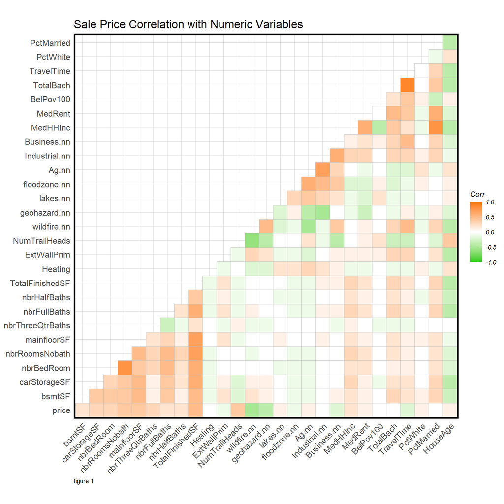

```r
ggcorrplot(
  round(cor(numericVars), 1),
  p.mat = cor_pmat(numericVars),
  colors = c("#25CB10", "white", "#FA7800"),
  type="lower",
  insig = "blank") +
  labs(title = "Sale Price Correlation with Numeric Variables", caption = "figure 1") +
  plotTheme()
```

```r
#just a sample of the data we looked at to check to see if the distributions were normal. histograms of our dependent and predictor variables

knownSales$LNlakes.nn <- log(knownSales$lakes.nn+1)
knownSales$LNTotalSF <- log(knownSales$TotalFinishedSF+1)
knownSales$LNAg <- log(knownSales$Ag.nn+1)
knownSales$LNIndustry <- log(knownSales$Industrial.nn+1)
```

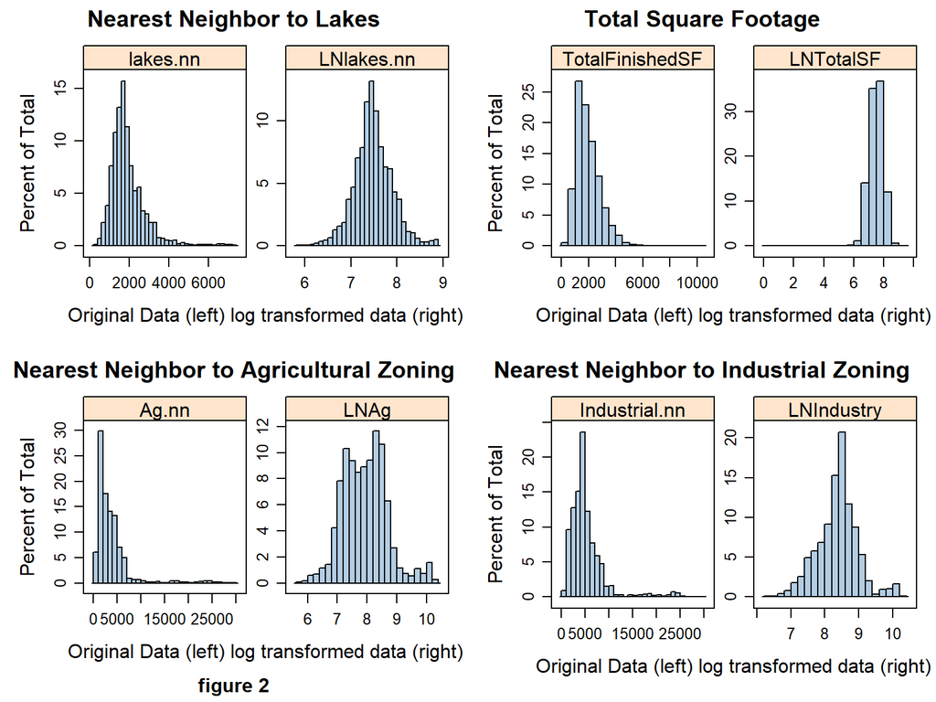

```r
#plot log transformed histograms
histlake <- histogram( ~ lakes.nn +LNlakes.nn,layout=c(2,1),data = knownSales,
                      main='Nearest Neighbor to Lakes', xlab='Original Data (left) log transformed data (right)', col="#B3CDE3", breaks = 25, scales='free')

histSF <- histogram( ~ TotalFinishedSF +LNTotalSF,layout=c(2,1),data = knownSales,
                      main='Total Square Footage', xlab='Original Data (left) log transformed data (right)', col="#B3CDE3", breaks = 25, scales='free')

histAG <- histogram( ~ Ag.nn +LNAg,layout=c(2,1),data = knownSales,
                      main='Nearest Neighbor to Agricultural Zoning', xlab='Original Data (left) log transformed data (right)', sub= 'figure 2', col="#B3CDE3", breaks = 25, scales='free')

histI <- histogram( ~ Industrial.nn +LNIndustry,layout=c(2,1),data = knownSales,
                      main='Nearest Neighbor to Industrial Zoning', xlab='Original Data (left) log transformed data (right)', col="#B3CDE3", breaks = 25, scales='free')

grid.arrange(histlake, histSF, histAG, histI, ncol=2, nrow=2)
```

```r
#separating data between test set and training set
knownSales <- HouseData %>%
  filter(.,toPredict == 0)
toPredictSales <- HouseData %>%
  filter(.,toPredict ==1)

#SCATTER PLOTS
#remove data observation that is out liar
knownSales <- knownSales%>%
  filter(MUSA_ID != 8197)

#Pearson Correlation Tests and Linear Relationship Plots

#bsmtSF
cor.test(knownSales$bsmtSF, knownSales$price, method = "pearson")
#marginal pearsons r of .21 but statistically significant

bsmtSFplot <- ggplot(data = knownSales, aes(x = bsmtSF, y = price)) +
  geom_point(size=2, shape=20)  +
  labs(x = 'Basement Square Footage',
       y = 'House Price',
       title = "Basement Square Footage \nand Sale Price",
       subtitle = "Boulder County, CO",
       caption = "figure 3.1") +
  geom_smooth(method = "lm", se=F, colour = "green") +
  plotTheme()

#carStorageSF
cor.test(knownSales$carStorageSF, knownSales$price, method = "pearson")
#marginal correlation value of .25 but statistically significant

carSFplot <- ggplot(data = knownSales, aes(x = carStorageSF, y = price)) +
  geom_point(size=2, shape=20)  +
  labs(x = 'Car Storage Square Footage',
       y = 'House Price',
       title = "Car Storage Square Footage \nand Sale Price",
       subtitle = "Boulder County, CO",
       caption = "figure 3.2") +
  geom_smooth(method = "lm", se=F, colour = "green") +
  plotTheme()

#total finished square footage
cor.test(knownSales$TotalFinishedSF, knownSales$price, method = "pearson")
#pearsons r of .49 and statistically significant

TSFplot <- ggplot(data = knownSales, aes(x = TotalFinishedSF, y = price)) +
  geom_point(size=2, shape=20)  +
  labs(x = 'Total Finished Square Footage',
       y = 'House Price',
       title = "Total Finished Square Footage \nand Sale Price",
       subtitle = "Boulder County, CO",
       caption = "figure 3.3") +
  geom_smooth(method = "lm", se=F, colour = "green") +
  plotTheme()

#travel time and sale price correlation
cor.test(knownSales$TravelTime, knownSales$price, method = "pearson")
#negative pearsons r - weak correlation but statistically significant

TTplot <- ggplot(data = knownSales, aes(x = TravelTime, y = price)) +
  geom_point(size=2, shape=20)  +
  labs(x = 'Aggregate Travel Time to Work',
       y = 'House Price',
       title = "Travel Time to Work \nand Sale Price",
       subtitle = "Boulder County, CO",
       caption = "figure 3.1") +
  geom_smooth(method = "lm", se=F, colour = "orange") +
  theme_ipsum_rc()
#correlation has a slightly negative relationship.

#Median rent and home price
cor.test(knownSales$MedRent, knownSales$price, method = "pearson")
#weak correlation but statistically significant

RentPlot <- ggplot(data = knownSales, aes(x = MedRent, y = price)) +
  geom_point(size=2, shape=20)  +
  labs(x = 'Median Rent',
       y = 'House Price',
       title = "Median Rent and Sale Price",
       subtitle = "Boulder County, CO",
       caption = "figure 3.5") +
  geom_smooth(method = "lm", se=F, colour = "green") +
  plotTheme()

#household income and home price
cor.test(knownSales$MedHHInc, knownSales$price, method = "pearson")
#marginal pearsons r of .18 and statistically significant

HHIncplot<- ggplot(data = knownSales, aes(x = MedHHInc, y = price)) +
  geom_point(size=2, shape=20)  +
  labs(x = 'Median Household Income',
       y = 'House Price',
       title = "Median Household Income \nand Sale Price",
       subtitle = "Boulder County, CO",
       caption = "figure 3.2") +
  geom_smooth(method = "lm", se=F, colour = "orange") +
  theme_ipsum_rc()

#percent married folks and home price
cor.test(knownSales$PctMarried, knownSales$price, method = "pearson")
#very weak correlation, almost none

MarriedPlot <- ggplot(data = knownSales, aes(x = PctMarried, y = price)) +
  geom_point(size=2, shape=20)  +
  labs(x = 'Percent Married',
       y = 'House Price',
       title = "Percent of Homeowners with \nMarried Status and Sale Price",
       subtitle = "Boulder County, CO",
       caption = "figure 3.3") +
  geom_smooth(method = "lm", se=F, colour = "orange") +
  theme_ipsum_rc()

#plot percent white and home price
cor.test(knownSales$PctWhite, knownSales$price, method = "pearson")
#very weak correlation

Whiteplot<-  ggplot(data = knownSales, aes(x = PctWhite, y = price)) +
  geom_point(size=2, shape=20)  +
  labs(x = 'Percent White',
       y = 'House Price',
       title = "Percent White Population \nand Sale Price",
       subtitle = "Boulder County, CO",
       caption = "figure 3.4") +
  geom_smooth(method = "lm", se=F, colour = "orange") +
  theme_ipsum_rc()
```

## Figure 3.2 Median Household income and sale price

## Figure 3.3 Percent of homeowners with married status and sale price

## Figure 3.4 Percent white population and sale price

percent of white population is positively correlated to the sales price, it should also considered that given Boulder county ebing predominantly white, will not have a strong contributor to predicting the sales prices.

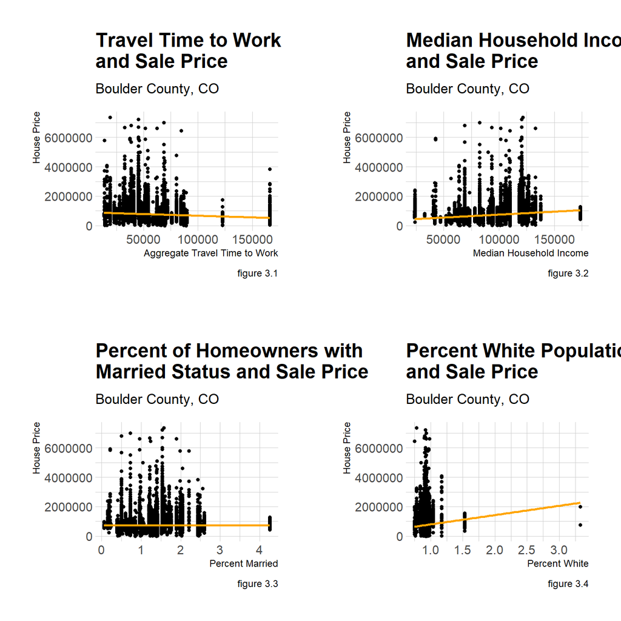

```r
#show grid plot in markdown
grid.arrange(TTplot, HHIncplot, MarriedPlot, Whiteplot, ncol=2, nrow =2)
```

```r
#Wildfire Proximity
wfplot<- ggplot() +
  geom_sf(data= tracts19, fill = 'grey99', color = 'black')+
  geom_sf(data = Wildfire_History,fill = 'red',alpha = .75) +
  geom_sf(data = wf_buffer_25,fill = 'red',color = NA,alpha = .1) +
  geom_sf(data = wf_buffer_5,fill = 'red',color = NA,alpha = .1) +
  geom_sf(data = wf_buffer_75,fill = 'red',color = NA,alpha = .1) +
  geom_sf(data = wf_buffer_1,fill = 'red',color = NA,alpha = .1) +
  geom_sf(data = knownSales, aes(colour = q5(price)),
          size = .4) +
  scale_colour_manual(values = paletteMap)+
  labs(title = "House Proximity to Wildfire Risk \nand Sale Price",
       subtitle = "Boulder County, CO",
       caption = 'figure 4.1') +
  mapTheme()+ theme_ipsum_rc()
cor.test(knownSales$wildfire.nn, knownSales$price, method = "pearson")

#Lakes Map
lakeplot<- ggplot() +
  geom_sf(data= tracts19, fill = 'grey99', color = 'black')+
  geom_sf(data = Lakes_Reservoir, fill = 'red', alpha = .85) +
  geom_sf(data = lake_buffer_25,fill = 'red',color = NA,alpha = .1) +
  geom_sf(data = lake_buffer_5,fill = 'red',color = NA,alpha = .1) +
  geom_sf(data = lake_buffer_75,fill = 'red',color = NA,alpha = .1) +
  geom_sf(data = lake_buffer_1,fill = 'red',color = NA,alpha = .1) +
  geom_sf(data = knownSales, aes(colour = q5(price)),
          size = .4) +
  scale_colour_manual(values = paletteMap)+
  labs(title = "House Proximity to Lakes and Reservoirs \nand Sale Price" ,
       subtitle = "Boulder County, CO",
       caption = 'figure 4.2') +
  mapTheme()+theme_ipsum_rc()
cor.test(knownSales$lakes.nn, knownSales$price, method = "pearson")

#Geohazard Plot
geoplot<- ggplot() +
  geom_sf(data= tracts19, fill = 'grey99', color = 'black')+
  geom_sf(data = GeoHazard, color= 'red', fill = 'red', alpha = .85) +
  geom_sf(data = geo_buffer_25,fill = 'red',color = NA,alpha = .1) +
  geom_sf(data = geo_buffer_5,fill = 'red',color = NA,alpha = .1) +
  geom_sf(data = geo_buffer_75,fill = 'red',color = NA,alpha = .1) +
  geom_sf(data = geo_buffer_1,fill = 'red',color = NA,alpha = .1) +
  geom_sf(data = knownSales, aes(colour = q5(price)),
          size = .4) +
  scale_colour_manual(values = paletteMap)+
  labs(title = "House Proximity to Geological Hazard Sites \nand Sale Price",
       subtitle = "Boulder County, CO",
       caption = 'figure 4.3') +
  mapTheme()+theme_ipsum_rc()
cor.test(knownSales$geohazard.nn, knownSales$price, method = "pearson")


#FloodRisk Plot
floodplot<- ggplot() +
  geom_sf(data= tracts19, fill = 'grey99', color = 'black')+
  geom_sf(data = FloodZone,color = 'red',fill = 'red', alpha = .85) +
  geom_sf(data = fl_buffer_25,fill = 'red',color = NA,alpha = .1) +
  geom_sf(data = fl_buffer_5,fill = 'red',color = NA,alpha = .1) +
  geom_sf(data = fl_buffer_75,fill = 'red',color = NA,alpha = .1) +
  geom_sf(data = fl_buffer_1,fill = 'red',color = NA,alpha = .1) +
  geom_sf(data = knownSales, aes(colour = q5(price)),
          size = .4) +
  scale_colour_manual(values = paletteMap)+
  labs(title = "House Proximity to Flood Zone \nand Sale Price",
       subtitle = "Boulder County, CO",
       caption = 'figure 4.4') +
  mapTheme()+theme_ipsum_rc()
cor.test(knownSales$floodzone.nn, knownSales$price, method = "pearson")

#Business and Commercial Zoning
Businessplot<- ggplot() +
  geom_sf(data= tracts19, fill = 'grey99', color = 'black')+
  geom_sf(data = BusinessCommercial,color = 'red',fill = 'red', alpha = .85) +
  geom_sf(data = BC_buffer_25,fill = 'red',color = NA,alpha = .1) +
  geom_sf(data = BC_buffer_5,fill = 'red',color = NA,alpha = .1) +
  geom_sf(data = BC_buffer_75,fill = 'red',color = NA,alpha = .1) +
  geom_sf(data = BC_buffer_1,fill = 'red',color = NA,alpha = .1) +
  geom_sf(data = knownSales, aes(colour = q5(price)),
          size = .4) +
  scale_colour_manual(values = paletteMap)+
  labs(title = "House Proximity to Business Zoning \nand Sale Price",
       subtitle = "Boulder County, CO",
       caption = 'figure 4.5') +
  mapTheme()+theme_ipsum_rc()
cor.test(knownSales$Business.nn, knownSales$price, method = "pearson")

#Industrial Zoning
Industryplot<- ggplot() +
  geom_sf(data= tracts19, fill = 'grey99', color = 'black')+
  geom_sf(data = Industrial,color = 'red',fill = 'red', alpha = .85) +
  geom_sf(data = I_buffer_25,fill = 'red',color = NA,alpha = .1) +
  geom_sf(data = I_buffer_5,fill = 'red',color = NA,alpha = .1) +
  geom_sf(data = I_buffer_75,fill = 'red',color = NA,alpha = .1) +
  geom_sf(data = I_buffer_1,fill = 'red',color = NA,alpha = .1) +
  geom_sf(data = knownSales, aes(colour = q5(price)),
          size = .4) +
  scale_colour_manual(values = paletteMap)+
  labs(title = "House Proximity to Industrial Zoning \nand Sale Price",
       subtitle = "Boulder County, CO",
       caption = 'figure 4.6') +
  mapTheme()+theme_ipsum_rc()
cor.test(knownSales$Industrial.nn, knownSales$price, method = "pearson")

#Agricultural zoning
Agplot<- ggplot() +
  geom_sf(data= tracts19, fill = 'grey99', color = 'black')+
  geom_sf(data = Ag,color = 'red',fill = 'red', alpha = .85) +
  geom_sf(data = AG_buffer_25,fill = 'red',color = NA,alpha = .1) +
  geom_sf(data = AG_buffer_5,fill = 'red',color = NA,alpha = .1) +
  geom_sf(data = AG_buffer_75,fill = 'red',color = NA,alpha = .1) +
  geom_sf(data = AG_buffer_1,fill = 'red',color = NA,alpha = .1) +
  geom_sf(data = knownSales, aes(colour = q5(price)),
          size = .4) +
  scale_colour_manual(values = paletteMap)+
  labs(title = "House Proximity to Agriculture\nand Sale Price",
       subtitle = "Boulder County, CO",
       caption = 'figure 4.7') +
  mapTheme()+theme_ipsum_rc()
cor.test(knownSales$Ag.nn, knownSales$price, method = "pearson")

#Streams Plot
#streamplot<- ggplot() +
#  geom_sf(data= tracts19, fill = 'grey99', color = 'black')+
#  geom_sf(data = Streams,
#          fill = 'red',
#          alpha = .85) +
#  geom_sf(data = Streams_buffer,
#          fill = 'red',
#          color = 'red',
#          alpha = .15) +
#  geom_sf(data = knownSales, aes(colour = q5(price)),
#          size = .4) +
#  scale_colour_manual(values = paletteMap)+
#  labs(title = "1/4 mi Stream Buffer and Home Sale Price",
#       subtitle = "Boulder County, CO",
#       caption = 'figure #') +
#  mapTheme()+plotTheme()
```

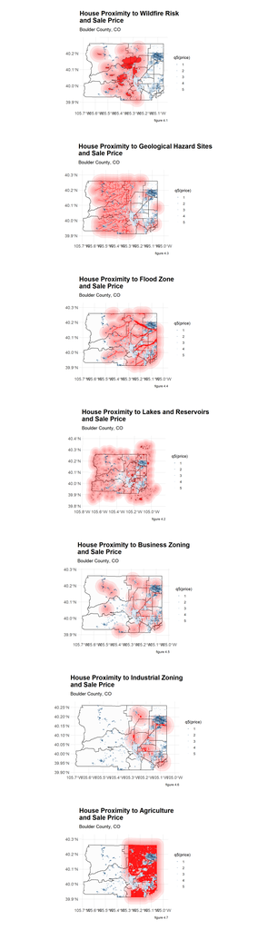

```r
#show grid maps in markdown
grid.arrange(wfplot, geoplot,
             floodplot,lakeplot, Businessplot, Industryplot,
             Agplot, ncol=1, nrow =7)
```

### **III. Methods**

```r
#Building Regression Model
knownSales$LNlakes.nn <- log(knownSales$lakes.nn+1)
knownSales_nog <- st_drop_geometry(knownSales)

reg <- lm(price ~ MedRent + HouseAge + PctMarried + BelPov100 + wildfire.nn + geohazard.nn + LNlakes.nn + floodzone.nn + Ag.nn + Business.nn + Industrial.nn + NumTrailHeads + bsmtSF + HeatingDscr + TotalBach + MedHHInc + TravelTime + nbrBedRoom + qualityCodeDscr + TotalFinishedSF + designCodeDscr, data = knownSales_nog)

summary(reg)
```

[output not shown]

```r
# Our adjusted R sq is 65.25% - not super great
broom::tidy(reg)%>%
  kable()%>%
  kable_styling()%>%
  footnote(general_title = "Regression Output",
           general = "Table 1")
```

[output not shown]

```r
#separate the test and training sets
inTrain <- createDataPartition(
  y = paste(knownSales$qualityCodeDscr, knownSales$designCodeDscr, knownSales$HeatingDscr),
  p = .60, list = FALSE)
boulder.training <- knownSales[inTrain,]
boulder.test <- knownSales[-inTrain,]

#training regression
reg.training <-lm(price ~ MedRent+ HouseAge+ PctMarried+BelPov100+wildfire.nn+geohazard.nn
                  +LNlakes.nn+floodzone.nn+Ag.nn+Business.nn+Industrial.nn+NumTrailHeads+bsmtSF+HeatingDscr+TotalBach+
                    MedHHInc+TravelTime+nbrBedRoom+qualityCodeDscr+
                    TotalFinishedSF+designCodeDscr, data = boulder.training)
```

### **IV. Results**

```r
broom::tidy(reg.training)%>%
      kable()%>%
      kable_styling()%>%
      footnote(general_title = "Training Regression Output",
                general = "Table 2")
```

| term | estimate | std.error | statistic | p.value |
| --- | --- | --- | --- | --- |
| (Intercept) | -399477.235468 | 108422.1028142 | -3.6844631 | 0.0002310 |
| MedRent | 106.269213 | 17.6651637 | 6.0157503 | 0.0000000 |
| HouseAge | 1643.091516 | 216.2176822 | 7.5992467 | 0.0000000 |
| PctMarried | -83359.668061 | 15543.7322788 | -5.3629120 | 0.0000001 |
| BelPov100 | -60.892646 | 15.2100407 | -4.0034505 | 0.0000631 |
| wildfire.nn | -20.683499 | 1.8313512 | -11.2941196 | 0.0000000 |
| geohazard.nn | -12.397897 | 2.0912638 | -5.9284234 | 0.0000000 |
| LNlakes.nn | 103874.362303 | 10957.2174955 | 9.4799946 | 0.0000000 |
| floodzone.nn | -2.264165 | 3.2823212 | -0.6898061 | 0.4903397 |
| Ag.nn | -11.746577 | 3.0775082 | -3.8169115 | 0.0001363 |
| Business.nn | 15.739222 | 3.1953141 | 4.9257200 | 0.0000009 |
| Industrial.nn | -5.616291 | 3.4574302 | -1.6244120 | 0.1043342 |
| NumTrailHeads | 14682.788720 | 812.5160731 | 18.0707671 | 0.0000000 |
| bsmtSF | 4.560893 | 8.0651097 | 0.5655091 | 0.5717462 |
| HeatingDscrElectric | -39941.571984 | 45616.9396372 | -0.8755864 | 0.3812858 |
| HeatingDscrElectric Wall Heat (1500W) | 68613.868794 | 232625.2414554 | 0.2949545 | 0.7680376 |
| HeatingDscrForced Air | -26440.611951 | 39737.0772860 | -0.6653889 | 0.5058243 |
| HeatingDscrGravity | -17021.431520 | 85064.2873527 | -0.2001008 | 0.8414077 |
| HeatingDscrHeat Pump | -101839.696319 | 121650.4203073 | -0.8371504 | 0.4025374 |
| HeatingDscrHot Water | 60465.809828 | 42106.6306043 | 1.4360163 | 0.1510437 |
| HeatingDscrNo HVAC | 252626.569309 | 233588.5277399 | 1.0815025 | 0.2795120 |
| HeatingDscrPackage Unit | -447430.820428 | 327807.8619921 | -1.3649179 | 0.1723240 |
| HeatingDscrRadiant Floor | 275111.171735 | 55997.4659810 | 4.9129218 | 0.0000009 |
| HeatingDscrVentilation Only | -408333.220300 | 327135.2880212 | -1.2482090 | 0.2119975 |
| HeatingDscrWall Furnace | 94320.391973 | 59488.1525096 | 1.5855324 | 0.1128919 |
| TotalBach | 34.123157 | 20.2946986 | 1.6813828 | 0.0927345 |
| MedHHInc | 1.040716 | 0.4700799 | 2.2139141 | 0.0268677 |
| TravelTime | -1.300889 | 0.4196388 | -3.1000199 | 0.0019430 |
| nbrBedRoom | 9591.890783 | 4988.6467523 | 1.9227440 | 0.0545539 |
| qualityCodeDscrAVERAGE + | -5709.524930 | 17474.4791966 | -0.3267351 | 0.7438783 |
| qualityCodeDscrAVERAGE ++ | 30270.110964 | 18052.5246757 | 1.6767799 | 0.0936315 |
| qualityCodeDscrEXCELLENT | 1237902.055557 | 39954.6815052 | 30.9826536 | 0.0000000 |
| qualityCodeDscrEXCELLENT + | 1662296.422135 | 84121.5320182 | 19.7606532 | 0.0000000 |
| qualityCodeDscrEXCELLENT++ | 1720674.105530 | 70536.0590387 | 24.3942478 | 0.0000000 |
| qualityCodeDscrEXCEPTIONAL 1 | 1216431.117215 | 86064.6290201 | 14.1339262 | 0.0000000 |
| qualityCodeDscrEXCEPTIONAL 2 | 1782344.804232 | 191111.5794268 | 9.3262000 | 0.0000000 |
| qualityCodeDscrFAIR | -91482.788609 | 45236.1808305 | -2.0223367 | 0.0431806 |
| qualityCodeDscrGOOD | 96005.813242 | 12365.6529496 | 7.7639097 | 0.0000000 |
| qualityCodeDscrGOOD + | 114748.788284 | 20750.0845751 | 5.5300395 | 0.0000000 |
| qualityCodeDscrGOOD ++ | 210857.634304 | 18959.2435238 | 11.1216270 | 0.0000000 |
| qualityCodeDscrLOW | -215650.762681 | 88915.2778392 | -2.4253511 | 0.0153194 |
| qualityCodeDscrVERY GOOD | 300013.288595 | 20672.8573623 | 14.5124248 | 0.0000000 |
| qualityCodeDscrVERY GOOD + | 619966.970739 | 35453.3401964 | 17.4868423 | 0.0000000 |
| qualityCodeDscrVERY GOOD ++ | 677064.810799 | 29292.7137756 | 23.1137619 | 0.0000000 |
| TotalFinishedSF | 176.288222 | 8.2095431 | 21.4735729 | 0.0000000 |
| designCodeDscr2-3 Story | -41439.263610 | 10954.5229066 | -3.7828451 | 0.0001564 |
| designCodeDscrBi-level | 58442.382913 | 24320.4457223 | 2.4030145 | 0.0162871 |
| designCodeDscrMULTI STORY- TOWNHOUSE | -158778.763945 | 15956.9929223 | -9.9504189 | 0.0000000 |
| designCodeDscrSplit-level | 24639.527127 | 16374.5768928 | 1.5047428 | 0.1324366 |

Training Regression Output  
Table 2

```r
#test regression on boulder.test
boulder.test <-
  boulder.test %>%
  mutate(SalePrice.Predict = predict(reg.training, boulder.test),
         SalePrice.Error = SalePrice.Predict - price,
         SalePrice.AbsError = abs(SalePrice.Predict - price),
         SalePrice.APE = (abs(SalePrice.Predict - price)) / SalePrice.Predict)%>%
  filter(price < 4000000)

mean(boulder.test$SalePrice.Predict, na.rm = T)
#[1] 725547.6 average home sale price in the test set is $725,547.6

mean(boulder.test$SalePrice.AbsError, na.rm = T)
#[1] 160063.7 - average absolute error is $160,063.7

mean(boulder.test$SalePrice.APE, na.rm = T)
#[1] 0.242315 - average absolute percent error is 24.2 % - model errs by 24.2%
```

[output not shown]

##### **Generalizibility**

```r
#Test Generalizability
fitControl <- trainControl(method = "cv", number = 100)
set.seed(825)

reg.cv <-
  train(price ~ MedRent+ HouseAge+ PctMarried+BelPov100+wildfire.nn+geohazard.nn
        +LNlakes.nn+floodzone.nn+Ag.nn+Business.nn+Industrial.nn+NumTrailHeads+bsmtSF+HeatingDscr+TotalBach+
          MedHHInc+TravelTime+nbrBedRoom+qualityCodeDscr+
          TotalFinishedSF+designCodeDscr, data = st_drop_geometry(knownSales),
        method = "lm", trControl = fitControl, na.action = na.pass)

reg.cv

reg.cv$resample[1:5,]

reg.cv.rs.min <- reg.cv$resample[80,]
```

[output not shown]

```r
reg.cv.rs.min %>%
  gather(Variable, Value) %>%
  group_by(Variable) %>%
  spread(Variable, Value) %>%
  kable(caption = "Regression Results of One Test Set") %>%
  kable_classic(full_width = F, html_font = "Helvetica")
```

Regression Results of One Test Set

| MAE | Resample | RMSE | Rsquared |
| --- | --- | --- | --- |
| 122222.550634774 | Fold080 | 180892.850508893 | 0.824215894882168 |

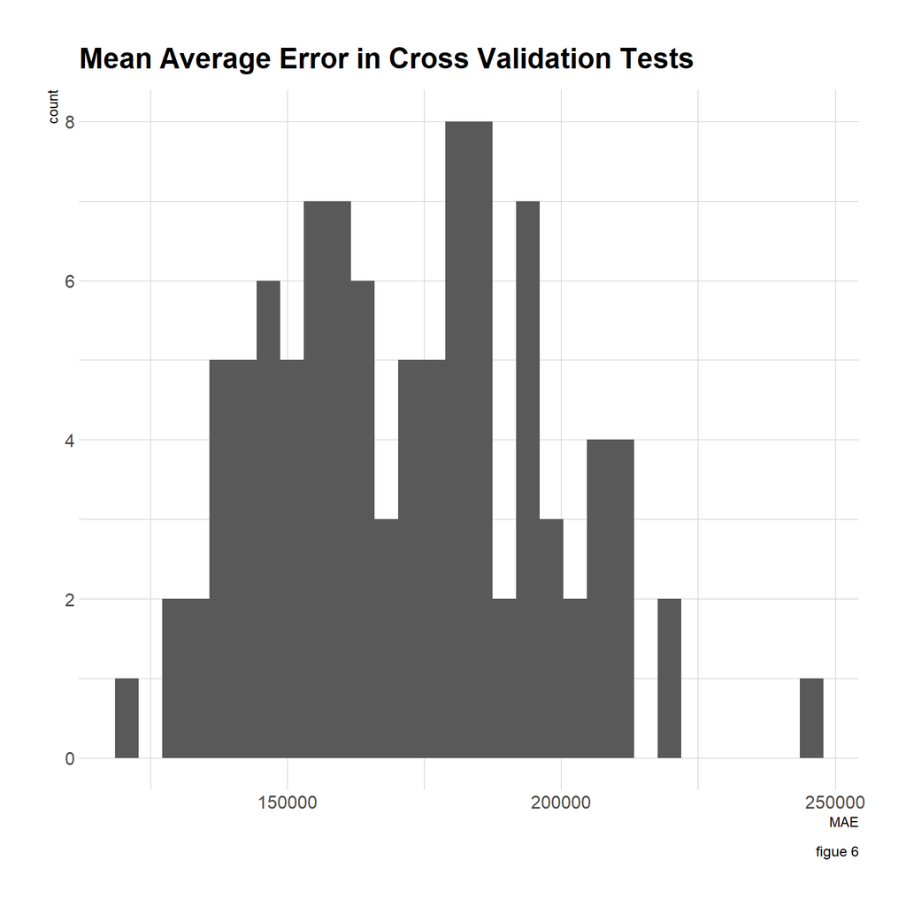

```r
ggplot(reg.cv$resample, aes(x=MAE)) +
  geom_histogram() +
  labs(title = "Mean Average Error in Cross Validation Tests",
       caption = "figue 6") +
  theme_ipsum_rc()
```

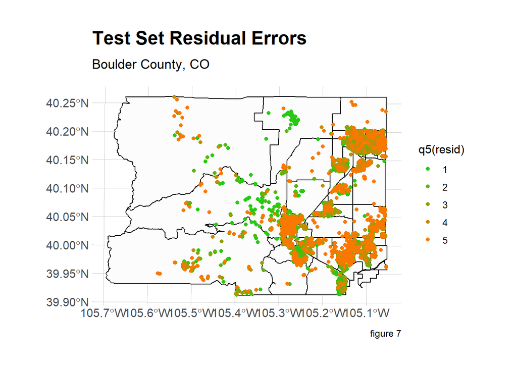

```r
#Map of test set residuals
library(modelr)

boulder.test$resid <-
  boulder.test %>%
  as_data_frame() %>%
  add_residuals(., reg.training, var = "resid") %>%
  dplyr::select(resid) %>%
  pull(resid)

ggplot() +
geom_sf(data= tracts19, fill = 'grey99', color = 'black')+
  geom_sf(data = boulder.test, aes(colour = q5(resid))) +
  scale_colour_manual(values = palette5) +
 labs(title = "Test Set Residual Errors",
      subtitle = "Boulder County, CO",
      caption = "figure 7") +
  theme_ipsum_rc()
```

```r
#Test Spatial Clustering

coords <- st_coordinates(knownSales)
neighborList <- knn2nb(knearneigh(coords, 5)) #5 nearest neighborhoods
spatialWeights <- nb2listw(neighborList, style="W") #not sure what is W here
knownSales$lagPrice <- lag.listw(spatialWeights, knownSales$price)

coords.test <-  st_c(boulder.test)
neighborList.test <- knn2nb(knearneigh(coords.test, 5))
spatialWeights.test <- nb2listw(neighborList.test, style="W")
```

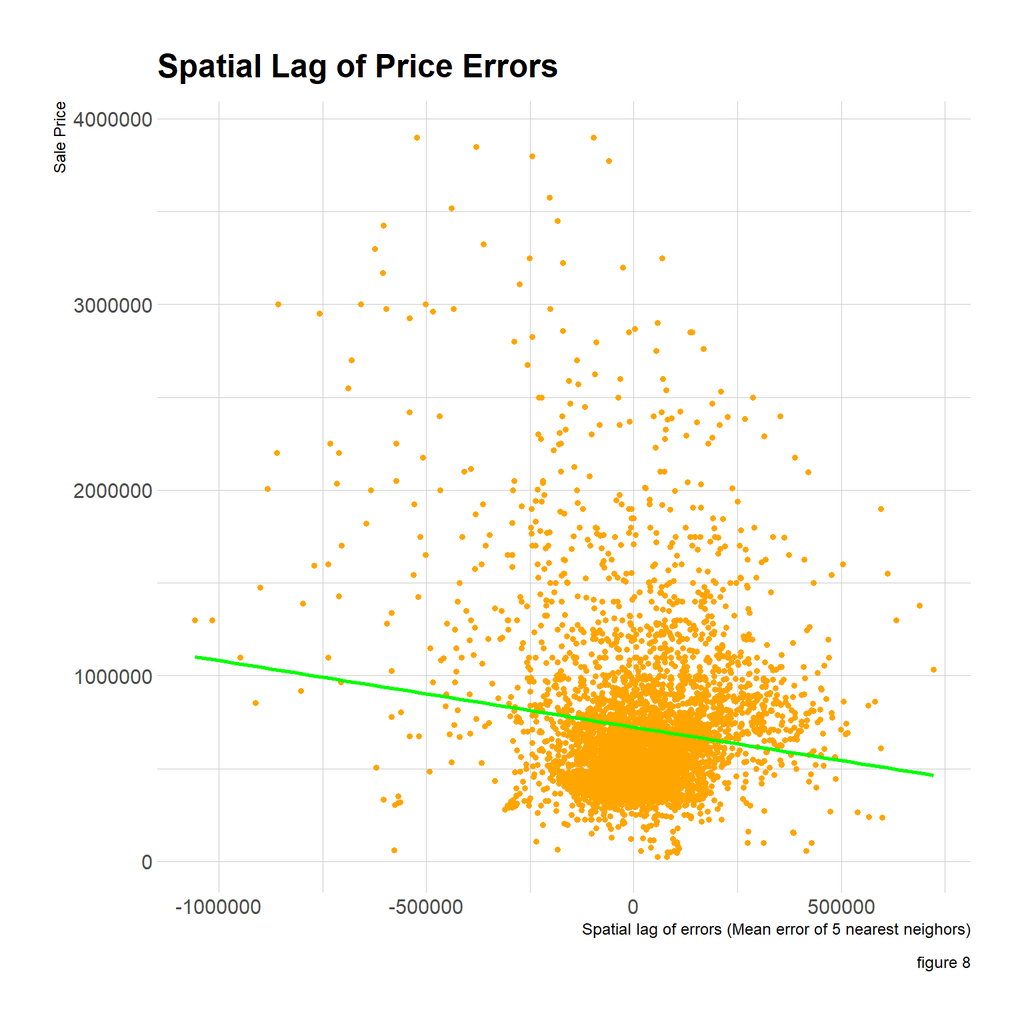

```r
#interpretation of price as function of spatial lag of price -
#as home sale price increases, so does the average price of a home's
# 5 nearest neighbors - the correlation of this spatial lag relationship
# is .79 and is highly statistically significant - substantial evidence
# fpr clustering of home prices.

boulder.test %>%
  mutate(lagPriceError = lag.listw(spatialWeights.test, SalePrice.Error)) %>%
  ggplot(aes(lagPriceError, price)) +
  geom_point(size=2, shape=20, color = 'orange') +
  stat_smooth(aes(lagPriceError, price),
             method = "lm", se = FALSE, size = 1, colour="green")+
  labs(x = 'Spatial lag of errors (Mean error of 5 nearest neighors)',
       y = 'Sale Price',
    title = "Spatial Lag of Price Errors",
    caption = "figure 8") +
   theme_ipsum_rc()
```

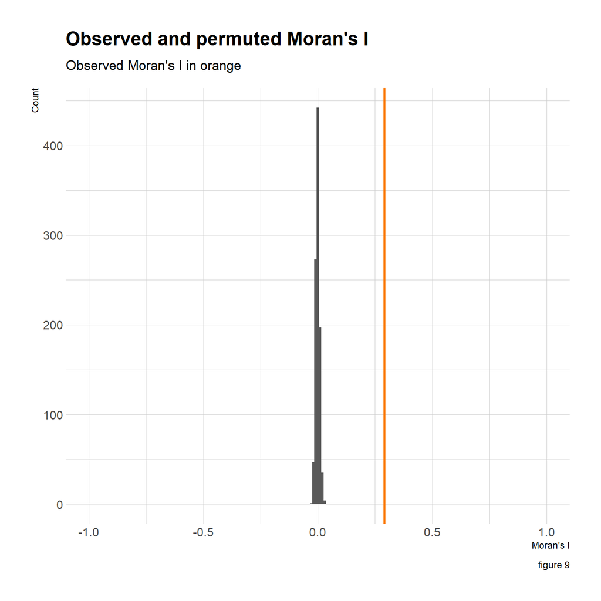

```r
#interpret

moranTest <- moran.mc(boulder.test$SalePrice.Error,
                      spatialWeights.test, nsim = 999)

ggplot(as.data.frame(moranTest$res[c(1:999)]), aes(moranTest$res[c(1:999)])) +
  geom_histogram(binwidth = 0.01) +
  geom_vline(aes(xintercept = moranTest$statistic), colour = "#FA7800",size=1) +
  scale_x_continuous(limits = c(-1, 1)) +
  labs(title="Observed and permuted Moran's I",
       subtitle= "Observed Moran's I in orange",
       x="Moran's I",
       y="Count",
       caption = "figure 9") +
  theme_ipsum_rc()
```

```r
#histogram to show frequency of all 999 randomly permutated I
#the observed I is higher than all 999 randomly generated I's suggests
#strong evidence for spatial autocorrelation.
#both spatial lag test and moran's I confirm spatial autocorrelation - this
#suggests that variation in price likely related to the spatial process
#has been omitted from our current model
```

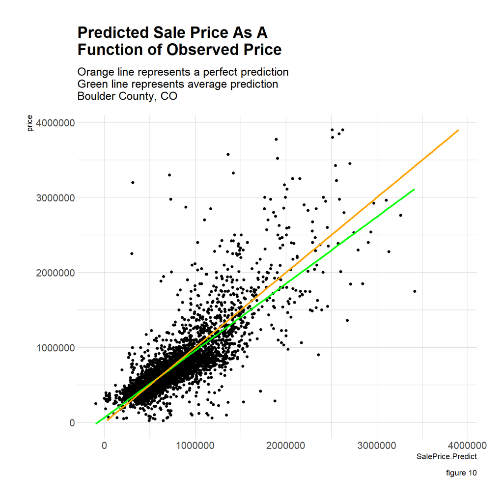

```r
ggplot(data = boulder.test, aes(x = SalePrice.Predict, y = price)) +
  geom_point(size=2, shape=20)  +
  labs(title = "Predicted Sale Price As A \nFunction of Observed Price",
       subtitle = "Orange line represents a perfect prediction\nGreen line represents average prediction \nBoulder County, CO",
       caption = "figure 10") +
  geom_smooth(method = "lm", se=F, colour = "green")+
  geom_smooth(data = boulder.test, aes(price, price), color = 'orange', se=F)+
  theme_ipsum_rc()
```

```r
##add neighborhood effects to plot
```